# Introduction to talusR

Chao-Jen Wong

Sarthy Lab, Seattle Children's Research Institute

chao-jen.wong@seattlechildrens.org

2025-05-27

# 1 Getting started

## 1.1 Intruduction

The `talusR` package provides a workflow for Talus mass-spectrum data—import, QC, differential analysis, and visualization. But it assumes that your data have already been processed by DIA-NN (e.g. `*.tsv` or `*.csv` outputs containing normalized, protein-level intensity values). It further expects one sample per mass-spectrometer run (with DIA-NN normalization applied across all runs), and that your sample metadata table includes a run column whose entries exactly match the sample names in the intensity signal file.

Key features include:

- **Data import & structure**  
  Import DIA-NN–processed protein intensities into S4 objects:
  - `TalusDataSet` for a whole dataset
  - `TalusDataSetList` (a `SimpleList` of `TalusDataSet`) for per-fraction splits

  Each object carries sample metadata and feature annotations.
- **Quality control**: Run PCA or other multivariate checks to confirm that technical replicates and fractions cluster as expected.
- **Differential analysis**: use a simple wrapper around `matrixTests` to t-test and `limma` to fit linear models, define contrasts, apply independent filtering by adjusted p-value or log-fold change thresholds, and return results in `TalusResult` or `TalusResultList` objects.
- **Visualization**: Create PCA scatterplots, volcano plots, per-protein intensity plots.
- **Bioconductor integration**: Built on `SummarizedExperiment` and `S4Vectors`, `talusR` classes inherit the generics and methods of the Bioconductor ecosystem, for convenient plug into annotation, pathway analysis, or reporting tools.

## 1.2 Installation

```r
# if you've installed the Bioconductor dependencies, then
devtools::install_github('chaochaowong/talusR',
                         build_vignettes = TRUE)

# if haven't installed the Bioconductor dependencies, then
BiocManager::install("chaochaowong/talusR",
                     dependencies = TRUE
                     build_vignettes = TRUE
)
```

## 1.3 Loading libraries

```r
library(talusR)
library(ggplot2)
library(dplyr)
```

# 2 Import Talus data

The core function `read_talus()` imports protein-level intensity signals for whole dataset or, if `split_by_fraction = TRUE`, splits by fractions.

## 2.1 Whole dataset

When `split_by_fraction = FALSE`, `read_talus()` returns a single `TalusDataSet` instance. This mode is ideal when:

- Your data have no fraction annotations
- You want to run PCA-based QC to verify that protein-level signals from each fraction cluster as expected

```r
# get paths
protein_file <- system.file('extdata', 'test_data.tsv',
                            package = 'talusR')
meta_file    <- system.file('extdata', 'test_meta.csv',
                            package = 'talusR')
```

```r
# without split by fraction -> return TalusDataSet
tds  <- talusR::read_talus(file = protein_file,
                           meta_file = meta_file,
                           which_proteinid = "Protein.Ids",
                           which_run = "Run",
                           remove_few_measurements = TRUE,
                           split_by_fraction = FALSE)
tds
```

```
#> class: TalusDataSet
#> dim: 1500 36
#> metadata(3): intensity_group metric log_transform
#> assays(1): abundance
#> rownames(1500): P82675;P82675-2 Q6ZSR9 ... Q5JTZ9
#>   Q9H078;Q9H078-2;Q9H078-3
#> rowData names(5): Protein.Group Protein.Ids Protein.Names Genes
#>   First.Protein.Description
#> colnames(36): 240805_Sarthy_DMSO_chrom_03.d 240805_Sarthy_DMSO_nuc_05.d
#>   ... 240805_Sarthy_DMSO_cyto_06.d 240805_Sarthy_Etopo_cyto_02.d
#> colData names(3): Run Tx Frx
#> intensity_group: protein
#> metric:          DIA-NN
#> log_transform:   log2
```

## 2.2 Per-fraction splits

When `split_by_fraction = TRUE`, `read_talus()` returns a `TalusDataSetList` instance—a `SimpleList` of `TalusDataSet` instances, one per fraction, each holding its protein-level signals.

```r
tdsl <- read_talus(file = protein_file,
                   meta_file = meta_file,
                   which_proteinid = "Protein.Ids",
                   which_fraction = "Frx",
                   which_sequence = NA,
                   which_run = "Run",
                   remove_few_measurements = TRUE,
                   split_by_fraction = TRUE,
                   log_transform = 'log2',
                   intensity_group = "protein",
                   metric = "DIA-NN")

tdsl
```

```
#> TalusDataSetList of length 3
#> names(3): chrom cyto nuc
#>
#> [[1]] — name: chrom
#> class: TalusDataSet
#> dim: 1269 12
#> metadata(3): intensity_group metric log_transform
#> assays(1): abundance
#> rownames(1269): P82675;P82675-2 Q6ZSR9 ... Q5JTZ9
#>   Q9H078;Q9H078-2;Q9H078-3
#> rowData names(5): Protein.Group Protein.Ids Protein.Names Genes
#>   First.Protein.Description
#> colnames(12): 240805_Sarthy_DMSO_chrom_03.d
#>   240805_Sarthy_DMSO_chrom_01.d ... 240805_Sarthy_Etopo_chrom_02.d
#>   240805_Sarthy_DMSO_chrom_04.d
#> colData names(3): Run Tx Frx
#> intensity_group: protein
#> metric:          DIA-NN
#> log_transform:   log2
#>
#> [[2]] — name: cyto
#> class: TalusDataSet
#> dim: 1435 12
#> metadata(3): intensity_group metric log_transform
#> assays(1): abundance
#> rownames(1435): P82675;P82675-2 Q6ZSR9 ... Q5JTZ9
#>   Q9H078;Q9H078-2;Q9H078-3
#> rowData names(5): Protein.Group Protein.Ids Protein.Names Genes
#>   First.Protein.Description
#> colnames(12): 240805_Sarthy_DMSO_cyto_01.d 240805_Sarthy_DMSO_cyto_02.d
#>   ... 240805_Sarthy_DMSO_cyto_06.d 240805_Sarthy_Etopo_cyto_02.d
#> colData names(3): Run Tx Frx
#> intensity_group: protein
#> metric:          DIA-NN
#> log_transform:   log2
#>
#> [[3]] — name: nuc
#> class: TalusDataSet
#> dim: 1226 12
#> metadata(3): intensity_group metric log_transform
#> assays(1): abundance
#> rownames(1226): P82675;P82675-2 Q6ZSR9 ... Q5JTZ9
#>   Q9H078;Q9H078-2;Q9H078-3
#> rowData names(5): Protein.Group Protein.Ids Protein.Names Genes
#>   First.Protein.Description
#> colnames(12): 240805_Sarthy_DMSO_nuc_05.d 240805_Sarthy_DMSO_nuc_01.d
#>   ... 240805_Sarthy_Etopo_nuc_01.d 240805_Sarthy_Etopo_nuc_03.d
#> colData names(3): Run Tx Frx
#> intensity_group: protein
#> metric:          DIA-NN
#> log_transform:   log2
```

# 3 QC

Use `plot_pca()` to assess sample clustering and variance structure.

## 3.1 `TalusDataSet`

Run PCA on the full dataset to verify that protein-level signals from each fraction cluster as expected.

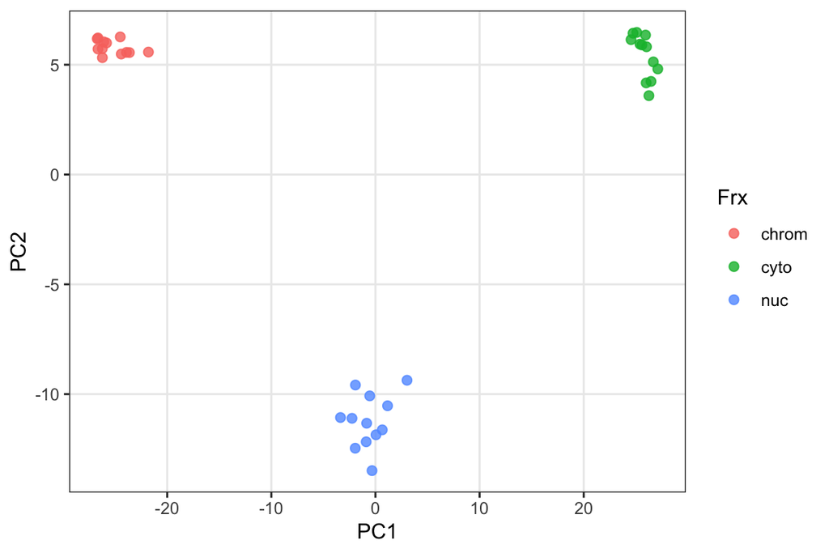

Figure 1: PCA on TalusDataSet

```r
talusR::plot_pca(tds, color_by='Frx')
```

## 3.2 `TalusDataSetList`

When using per-fraction splits, perform PCA on each fraction independently:

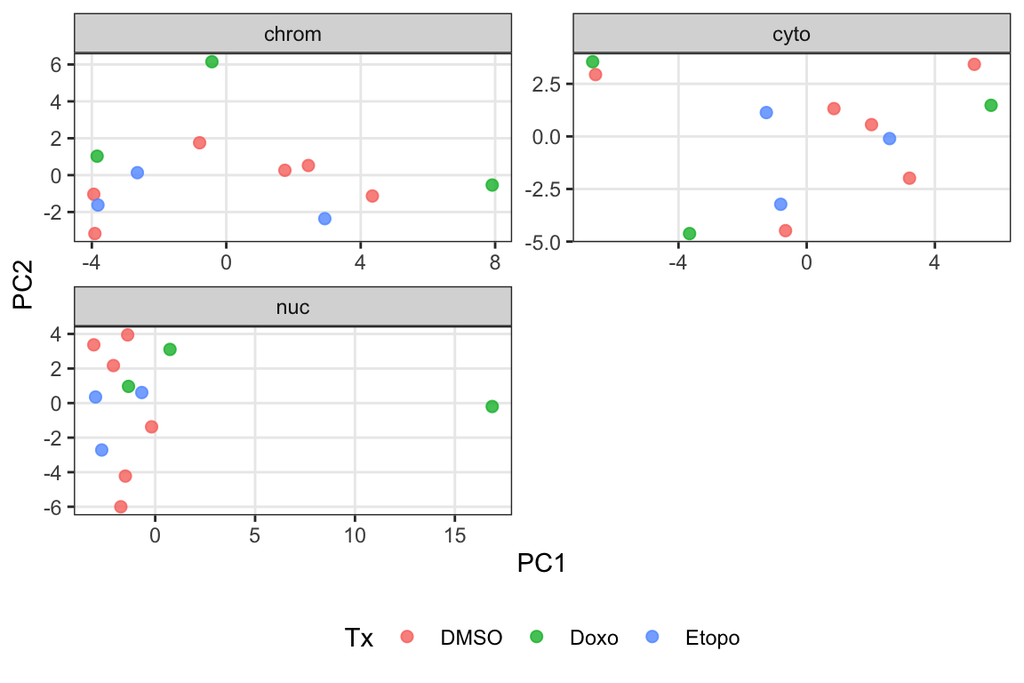

Figure 2: PCA performed separately on each fraction in the TalusDataSetList instance

```r
plot_pca(tdsl, color_by='Tx')
```

# 4 Differential analysis and visualization

**Core statistical methods:**

- `talus_limma`: a wrapper function for `limma::lmFit()` to fit linear models and test contrasts.
- `talus_row_t_welch`: a wrapper function for `matrixTests::row_t_welch()` to perform per-protein Welch’s t-tests.

**Summary & visualization:**

- `summary_talus`: summarize differential results, flag significant proteins, and return a `data.frame` of significant proteins.
- `plot_volcano`: create a volcano plot of log-fold changes vs adjusted p-values.
- `plot_per_protein`: display protein intensity profiles across fractions or conditions.

## 4.1 `limma`

Use `talus_limma()` to fit linear models with empirical Bayesian and moderate t-statistics across conditions (e.g. drug treatment) to perform differential analysis.

Here the condition group is `Tx`: *DMSO*, *etopo*, and *doxo*. Set the factor levels so that *DMSO* is the reference:

```r
tx_levels <- c('DMSO', 'Etopo', 'Doxo')
tdsl <- endoapply(tdsl, function(x) {
  colData(x)$Tx <- factor(colData(x)$Tx, levels = tx_levels)
  x
})
```

Next, run `talus_limma()` with a `~ 0 + Tx` design formula to compare each treatment against the `DMSO` control:

```r
res_limma <- talus_limma(tdsl, design = ~ 0 + Tx)
```

Finally, summarize and filter for significant proteins with with adjusted p-value < 0.05 and |log₂ fold change| > 0.5.

```r
limma_filt <- summary_talus(res_limma[['chrom']],
                            alpha = 0.05,
                            lfc_threshold = 0.5)
```

```
#>
#> TxEtopo_vs_TxDMSO :
#>
#> Threshold: alpha < 0.05; |lfc_threshod| > 0.5
#> Total features: 1269
#> Up-regulated:   1
#> Down-regulated: 1
#>
#>
#> TxDoxo_vs_TxDMSO :
#>
#> Threshold: alpha < 0.05; |lfc_threshod| > 0.5
#> Total features: 1269
#> Up-regulated:   2
#> Down-regulated: 0
```

```r
limma_filt
```

```
#> $TxEtopo_vs_TxDMSO
#>                                  id      logFC  AveExpr          t      P.Value
#> 1 P11388;P11388-2;P11388-3;P11388-4 -0.8769478 18.53434 -13.717557 5.507541e-08
#> 2                            P27694  0.8630436 16.38714   8.934821 3.400613e-06
#>      adj.P.Val        B                     Protein.Group
#> 1 6.614556e-05 8.195588 P11388;P11388-2;P11388-3;P11388-4
#> 2 2.042068e-03 4.853289                            P27694
#>                         Protein.Ids Protein.Names Genes
#> 1 P11388;P11388-2;P11388-3;P11388-4   TOP2A_HUMAN TOP2A
#> 2                            P27694    RFA1_HUMAN  RPA1
#>                          First.Protein.Description
#> 1                        DNA topoisomerase 2-alpha
#> 2 Replication protein A 70 kDa DNA-binding subunit
#>
#> $TxDoxo_vs_TxDMSO
#>       id    logFC  AveExpr         t      P.Value    adj.P.Val        B
#> 1 Q9H8H0 1.298674 14.40518 12.532423 1.339523e-07 0.0001615464 7.586870
#> 2 Q9UMY1 1.006518 14.53278  8.657043 4.554389e-06 0.0027462964 4.613002
#>   Protein.Group Protein.Ids Protein.Names Genes First.Protein.Description
#> 1        Q9H8H0      Q9H8H0   NOL11_HUMAN NOL11      Nucleolar protein 11
#> 2        Q9UMY1      Q9UMY1    NOL7_HUMAN  NOL7       Nucleolar protein 7
```

Visualize the statistiics by `plot_volcano()`:

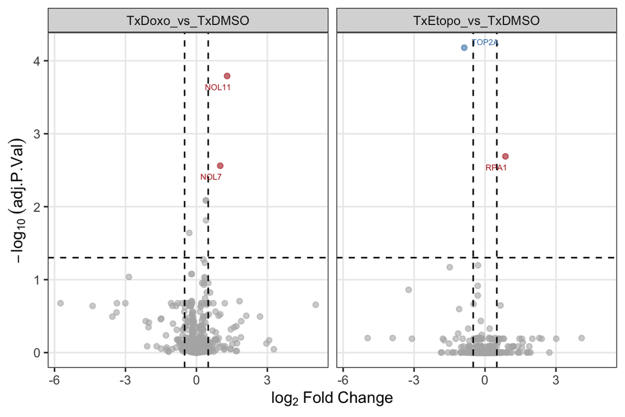

```r
plot_volcano(res_limma[['chrom']],
             alpha = 0.05,
             lfc_threshold = 0.5,
             use_adjP = TRUE,
             label_top_n=10)
```

## 4.2 t-test

Apply `talus_row_t_welch()` to perform per-protein Welch’s t-tests on the `TalusDataSetList`:

```r
res_t <- talus_row_t_welch(tdsl, design = ~ 0 + Tx)
names(res_t)
```

```
#> [1] "chrom" "cyto"  "nuc"
```

Filter significant proteins using summary_talus() (adjusted p-value < 0.05, |log₂FC| > 0.5):

```r
# show contrast level
cat('\nContrast levels:\n')
```

```
#>
#> Contrast levels:
```

```r
names(res_t[['chrom']])
```

```
#> [1] "TxEtopo-vs-TxDMSO" "TxDoxo-vs-TxDMSO"
```

```r
# summarize the result per fraction
ttest_filt <- summary_talus(res_t[['chrom']],
                            alpha = 0.05,
                            lfc_threshold = 0.5)
```

```
#>
#> TxEtopo-vs-TxDMSO :
#>
#> Threshold: alpha < 0.05; |lfc_threshod| > 0.5
#> Total features: 1269
#> Up-regulated:   1
#> Down-regulated: 1
#>
#>
#> TxDoxo-vs-TxDMSO :
#>
#> Threshold: alpha < 0.05; |lfc_threshod| > 0.5
#> Total features: 1269
#> Up-regulated:   1
#> Down-regulated: 0
```

Visualize the statistics by `plot_volcano()`.

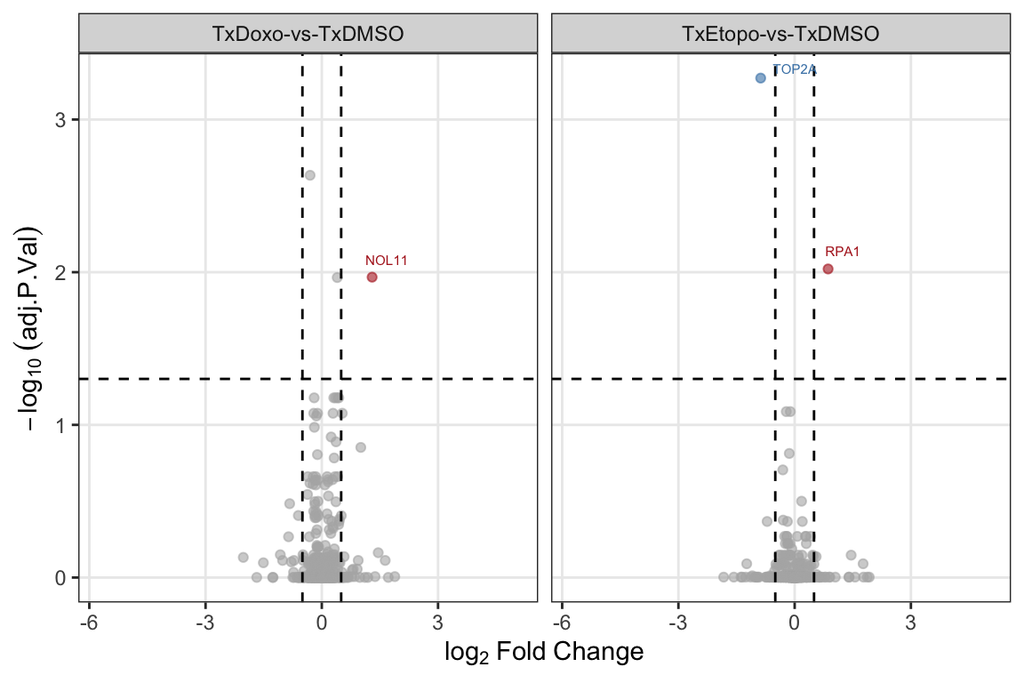

```r
# try to re-arrange the contrast_levels
plot_volcano(res_t[['chrom']],
             alpha = 0.05,
             lfc_threshold = 0.5,
             use_adjP = TRUE,
             contrast_levels = names(res_t[['chrom']])[c(2, 1)],
             label_top_n=10)
```

## 4.3 Per-protein plot

Extract a protein ID (e.g. TOP2A) and plot the intensities across conditions (e.g., fractions and treatments):

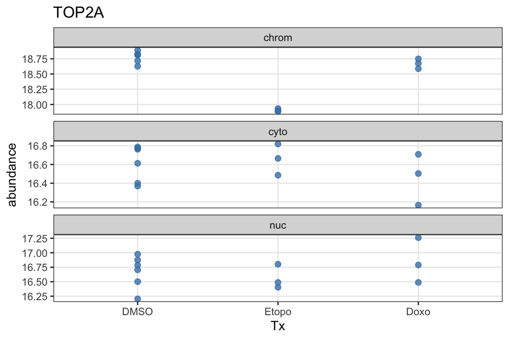

```r
protein_id <- as.data.frame(rowData(tdsl[[1]])) %>%
  dplyr::filter(Genes == 'TOP2A') %>% pull(Protein.Group)

plot_per_protein(tdsl,
                 protein_id = 'P11388;P11388-2;P11388-3;P11388-4',
                 group_by = 'Tx') +
  labs(title = 'TOP2A')
```

Or just for *chrom* fraction only:

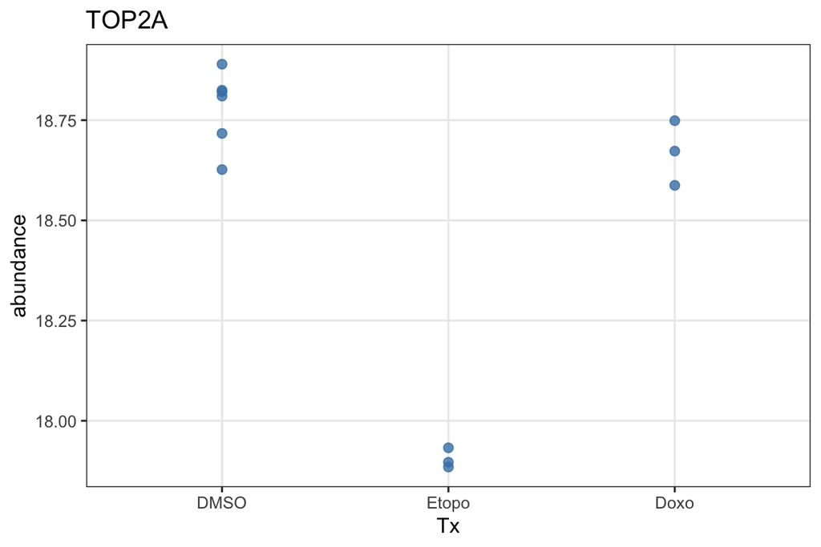

```r
plot_per_protein(tdsl[['chrom']],
                 protein_id = 'P11388;P11388-2;P11388-3;P11388-4',
                 group_by = 'Tx') +
  labs(title = 'TOP2A')
```